# Future Droughts in the Potohar Plateau under CMIP6 Scenarios — complete analysis

# 8 Validation and uncertainty (IV)

## 8.1 Cross-comparison of observed indices (stations, CHIRPS, ERA5-Land, CRU)

```r
cat_scores <- function(a, b, thr = THR) { A <- a <= thr; B <- b <= thr; ok <- !is.na(A) & !is.na(B); A <- A[ok]; B <- B[ok]
  hits <- sum(A & B); miss <- sum(!A & B); fa <- sum(A & !B)
  c(POD = hits / (hits + miss), FAR = fa / max(hits + fa, 1), CSI = hits / max(hits + miss + fa, 1)) }
CC <- rbindlist(lapply(ST_EVAL_V$pr, function(s) { j <- st_cells[s]; sx <- STX[[s]]   # v3.1: eligible stations only
  ref <- all_indices(OBS$chirps_pr[, j], OBS$pm_et0[, j], MON_OBS, YR_OBS, scales = c(3, 12))
  e5 <- all_indices(OBS$e5l_pr[, j], OBS$pm_et0[, j], MON_OBS, YR_OBS, scales = c(3, 12))
  cr <- all_indices(OBS$cru_pr[, j], OBS$cru_pet[, j], MON_OBS, YR_OBS, scales = c(3, 12))
  srcs <- list(CHIRPS = ref, `ERA5-Land` = e5, CRU = cr)
  ixs <- c("SPI3", "SPI12", if (s %in% ST_EVAL_V$ET0) c("SPEI3", "SPEI12"))   # SPEI only with an eligible station ET0
  rbindlist(lapply(ixs, function(ix) rbindlist(lapply(names(srcs), function(gn) {
    a <- srcs[[gn]][[ix]][, 1]; b <- sx$idx[[ix]][, 1]; sc <- cat_scores(a, b)
    data.table(station = s, index = ix, gridded = gn, r = cor(a, b, use = "complete.obs"), RMSE = sqrt(mean((a - b)^2, na.rm = TRUE)),
               POD = sc["POD"], FAR = sc["FAR"], CSI = sc["CSI"]) }))))
}))
CCR <- rbindlist(lapply(c("SPI3", "SPI12", "SPEI3", "SPEI12"), function(ix) rbindlist(lapply(c(`ERA5-Land` = "e5l", CRU = "cru"), function(g) {
  a <- IDX_REG[[g]][[ix]][, 1]; b <- IDX_REG$grid[[ix]][, 1]; sc <- cat_scores(a, b)
  data.table(index = ix, r = cor(a, b, use = "complete.obs"), POD = sc["POD"], CSI = sc["CSI"]) }), idcol = "vs CHIRPS-PM")))
KEY$crosscomp_station <- CC[, .(r = mean(r), CSI = mean(CSI)), by = .(gridded, index)]; KEY$crosscomp_regional <- CCR
fwrite(CC, file.path(ROOT, "11_validation_uncertainty", "crosscomparison_station_vs_gridded.csv"))
fwrite(CCR, file.path(ROOT, "11_validation_uncertainty", "crosscomparison_regional.csv"))
knitr::kable(KEY$crosscomp_station, digits = 3, caption = "Station vs gridded indices at the station cell (mean over stations)")
```

Station vs gridded indices at the station cell (mean over stations)

| gridded | index | r | CSI |
| --- | --- | --- | --- |
| CHIRPS | SPI3 | 0.560 | 0.221 |
| ERA5-Land | SPI3 | 0.379 | 0.199 |
| CRU | SPI3 | 0.485 | 0.208 |
| CHIRPS | SPI12 | 0.443 | 0.182 |
| ERA5-Land | SPI12 | 0.143 | 0.153 |
| CRU | SPI12 | 0.311 | 0.119 |

```r
knitr::kable(CCR, digits = 3, caption = "Regional indices from ERA5-Land and CRU vs CHIRPS-PM")
```

Regional indices from ERA5-Land and CRU vs CHIRPS-PM

| vs CHIRPS-PM | index | r | POD | CSI |
| --- | --- | --- | --- | --- |
| ERA5-Land | SPI3 | 0.554 | 0.456 | 0.271 |
| CRU | SPI3 | 0.775 | 0.608 | 0.457 |
| ERA5-Land | SPI12 | 0.175 | 0.342 | 0.158 |
| CRU | SPI12 | 0.702 | 0.684 | 0.510 |
| ERA5-Land | SPEI3 | 0.720 | 0.709 | 0.452 |
| CRU | SPEI3 | 0.829 | 0.684 | 0.466 |
| ERA5-Land | SPEI12 | 0.530 | 0.598 | 0.325 |
| CRU | SPEI12 | 0.763 | 0.695 | 0.543 |

## 8.2 Table II robustness datasets: PERSIANN-CDR rainfall range and ESA CCI soil moisture (v2.1)

Table II assigns two further roles to free datasets: - **PERSIANN-CDR** (daily, 0.25°, from 1983; GEE) provides a rainfall-uncertainty range for SPI and SPEI, alongside CHIRPS, ERA5-Land and CRU TS. - **C3S/ESA CCI satellite soil moisture** (COMBINED active + passive, monthly CDR v202505; CDS) validates agricultural drought. Its anomalies were standardised per calendar month over 1985–2014 and correlated with SPI-k and SPEI-k.

Both datasets were downloaded with `scripts/01m_download_robustness_obs.py` to the folder `paths.downscaling_additional` of `config.yaml`, and every file is listed in `MANIFEST_sha256.csv`.

```r
ADDP <- cfg$paths$downscaling_additional
grid_from_nc <- function(files, var, lonname = "lon", latname = "lat") {   # [time x ANA cell] for 1981-2024 (NA where not covered)
  M <- matrix(NA_real_, length(DATES_OBS), nrow(ANA))
  for (f in files) { nc <- nc_open(f); lo <- round(ncvar_get(nc, lonname), 3); la <- round(ncvar_get(nc, latname), 3); v <- ncvar_get(nc, var)
    tt <- ncvar_get(nc, "time"); tu <- ncatt_get(nc, "time", "units")$value; nc_close(nc)
    d0 <- as.Date(sub("^days since ([0-9-]+).*", "\\1", tu)); dts <- if (grepl("^days since", tu)) d0 + tt else as.Date(NA)
    ym <- match(format(dts, "%Y-%m"), format(DATES_OBS, "%Y-%m")); il <- match(round(ANA$lon, 3), lo); ia <- match(round(ANA$lat, 3), la)
    for (k in seq_along(ym)) if (!is.na(ym[k])) M[ym[k], ] <- v[cbind(il, ia, k)] }
  M }
# ---- PERSIANN-CDR: four-source rainfall range ----
pf <- list.files(file.path(ADDP, "persiann_cdr"), "\\.nc$", full.names = TRUE)
HAS_PERS <- length(pf) > 0
if (HAS_PERS) {
  OBS$pers_pr <- grid_from_nc(pf, "pr")
  P_pers <- wmean(ifelse(is.na(OBS$pers_pr), 0, OBS$pers_pr), W_REG); P_pers[rowSums(!is.na(OBS$pers_pr)) == 0] <- NA
  i83 <- which(YR_OBS >= 1983)
  idx_pers <- lapply(all_indices(P_pers[i83], REG$ET0_pm[i83], MON_OBS[i83], YR_OBS[i83], start = c(1983, 1)), function(m) { o <- matrix(NA_real_, length(DATES_OBS), 1); o[i83, ] <- m; o })
  srcP <- list(CHIRPS = list(P = REG$P_chirps, I = IDX_REG$grid), `ERA5-Land` = list(P = REG$P_e5l, I = IDX_REG$e5l), `CRU TS 4.10` = list(P = REG$P_cru, I = IDX_REG$cru),
               `PERSIANN-CDR` = list(P = P_pers, I = idx_pers))
  per <- YR_OBS >= 1985 & YR_OBS <= 2024
  RR <- rbindlist(lapply(names(srcP), function(nm) { s <- srcP[[nm]]; a <- data.table(year = YR_OBS, P = s$P)[year >= 1985, .(P = sum(P)), by = year]
    t <- tfpw(a$P); x3 <- s$I$SPI3[, 1]; ch <- IDX_REG$grid$SPI3[, 1]; ok <- per & !is.na(x3) & !is.na(ch)
    data.table(source = nm, P_1985_2014 = mean(a[year <= 2014]$P), P_trend_mm_dec = 10 * t[["slope"]], P_trend_p = t[["p"]],
               r_SPI3_vs_CHIRPS = cor(x3[ok], ch[ok]), drought_agree_vs_CHIRPS = mean((x3[ok] <= THR) == (ch[ok] <= THR)),
               SPI3_drought_pct_1985_2024 = 100 * mean(x3[per] <= THR, na.rm = TRUE), SPEI3_drought_pct_1985_2024 = 100 * mean(s$I$SPEI3[per, 1] <= THR, na.rm = TRUE),
               SPI12_Dec_trend_dec = 10 * tfpw(s$I$SPI12[MON_OBS == 12 & YR_OBS >= 1985, 1])[["slope"]]) }))
  KEY$rainfall_range <- RR
  fwrite(RR, file.path(ROOT, "11_validation_uncertainty", "rainfall_uncertainty_range_4_sources.csv"))
  knitr::kable(RR, digits = 3, caption = "Rainfall-uncertainty range (Table II): four precipitation sources, regional series 1985–2024")
}
```

Rainfall-uncertainty range (Table II): four precipitation sources, regional series 1985–2024

| source | P_1985_2014 | P_trend_mm_dec | P_trend_p | r_SPI3_vs_CHIRPS | drought_agree_vs_CHIRPS | SPI3_drought_pct_1985_2024 | SPEI3_drought_pct_1985_2024 | SPI12_Dec_trend_dec |
| --- | --- | --- | --- | --- | --- | --- | --- | --- |
| CHIRPS | 786.172 | 64.860 | 0.001 | 1.000 | 1.000 | 14.375 | 15.000 | 0.458 |
| ERA5-Land | 1025.000 | -97.087 | 0.001 | 0.553 | 0.815 | 18.333 | 20.625 | -0.500 |
| CRU TS 4.10 | 887.929 | 28.783 | 0.217 | 0.784 | 0.890 | 14.167 | 17.083 | 0.173 |
| PERSIANN-CDR | 836.452 | -2.459 | 0.904 | 0.752 | 0.873 | 16.250 | 16.458 | -0.012 |

```r
# ---- ESA CCI soil moisture vs SPI/SPEI ----
sf_ <- list.files(file.path(ADDP, "esa_cci_sm"), "^c3s_sm_combined_monthly_potohar_[0-9]{4}\\.nc$", full.names = TRUE)
HAS_SM <- length(sf_) >= 30
if (HAS_SM) {
  SMg <- grid_from_nc(sf_, "sm")
  okw <- !is.na(SMg); SMr <- rowSums(ifelse(okw, SMg, 0) * matrix(W_REG, nrow(SMg), ncol(SMg), byrow = TRUE)) / rowSums(okw * matrix(W_REG, nrow(SMg), ncol(SMg), byrow = TRUE))
  SMr[rowSums(okw * matrix(W_REG, nrow(SMg), ncol(SMg), byrow = TRUE)) < 0.5 * sum(W_REG)] <- NA      # at least half of the region observed
  SMz <- SMr; for (m in 1:12) { i <- MON_OBS == m; r <- i & YR_OBS >= BASE[1] & YR_OBS <= BASE[2]; SMz[i] <- (SMr[i] - mean(SMr[r], na.rm = TRUE)) / sd(SMr[r], na.rm = TRUE) }
  rabi <- MON_OBS %in% c(11, 12, 1, 2, 3, 4)
  SMC <- rbindlist(lapply(c("SPI", "SPEI"), function(ty) rbindlist(lapply(c(1, 3, 6, 12), function(k) { x <- IDX_REG$grid[[paste0(ty, k)]][, 1]; ok <- !is.na(x) & !is.na(SMz)
    data.table(index = paste0(ty, "-", k), n_months = sum(ok), r_all = cor(x[ok], SMz[ok]), r_rabi = cor(x[ok & rabi], SMz[ok & rabi]),
               drought_agree = mean((x[ok] <= THR) == (SMz[ok] <= -1)), hit_rate = sum(x[ok] <= THR & SMz[ok] <= -1) / max(1, sum(SMz[ok] <= -1))) }))))
  KEY$soil_moisture_check <- list(table = SMC, best = SMC[which.max(r_all)], months_with_data = sum(!is.na(SMz)), period = paste(range(YR_OBS[!is.na(SMz)]), collapse = "–"))
  fwrite(SMC, file.path(ROOT, "11_validation_uncertainty", "soil_moisture_vs_indices.csv"))
  save_table(SMC, "S5", "Agreement of regional SPI-k and SPEI-k with standardised ESA CCI soil-moisture anomalies (Table II validation of agricultural drought)", "TableS5_soil_moisture",
             note = "C3S/ESA CCI SM COMBINED v202505, monthly, standardised per calendar month over 1985–2014; months with < 50% of the region observed excluded. Rabi: November–April. Drought: index ≤ −1 and SM anomaly ≤ −1.", digits = 3)
  SMC
}
```

| index | n_months | r_all | r_rabi | drought_agree | hit_rate |
| --- | --- | --- | --- | --- | --- |
| SPI-1 | 525 | 0.5938614 | 0.6486660 | 0.8361905 | 0.4202899 |
| SPI-3 | 523 | 0.4743910 | 0.5481750 | 0.8221797 | 0.3913043 |
| SPI-6 | 520 | 0.3560018 | 0.4184935 | 0.8211538 | 0.3333333 |
| SPI-12 | 514 | 0.2175977 | 0.2476732 | 0.7723735 | 0.1911765 |
| SPEI-1 | 525 | 0.6970987 | 0.7364296 | 0.8647619 | 0.5797101 |
| SPEI-3 | 523 | 0.5494037 | 0.6405585 | 0.8374761 | 0.4492754 |
| SPEI-6 | 520 | 0.4268808 | 0.5021792 | 0.8173077 | 0.4057971 |
| SPEI-12 | 514 | 0.3090111 | 0.3376311 | 0.7840467 | 0.2794118 |

```r
# v2 item 4c: NDMC/PMD drought bulletins recovered from Internet Archive snapshots (01l_download_bulletins.py)
bul_dir <- file.path(RAW, "pmd_bulletins", "wayback")
pdfs <- if (dir.exists(bul_dir)) list.files(bul_dir, "\\.pdf$", full.names = TRUE) else character()
MONTHS_RX <- "(January|February|March|April|May|June|July|August|September|October|November|December)"
POT_RX <- "Potohar|Pothohar|Pothwar|Potwar|Attock|Chakwal|Jhelum|Rawalpindi|Islamabad Capital Territory|\\bICT\\b"   # NOT plain "Islamabad" (NDMC letterhead)
DRY_RX <- "drought|dry spell|moisture stress|water stress"   # explicit drought statements only (not temperature/rainfall tables)
NEG_RX <- "no drought|normal condition|drought.{0,20}(not|no longer)|above normal|near normal|wet condition"
BUL <- if (length(pdfs)) cached(paste0("bulletins_", length(pdfs)), rbindlist(lapply(pdfs, function(f) {
  tx <- tryCatch(paste(pdftools::pdf_text(f), collapse = " "), error = function(e) "")
  tx <- gsub("\\s+", " ", tx); if (nchar(tx) < 200) return(data.table(file = basename(f), type = "no text (scanned)"))
  latin <- nchar(gsub("[^A-Za-z]", "", tx)) / nchar(gsub("\\s", "", tx))
  if (latin < 0.5) return(data.table(file = basename(f), type = "Urdu bulletin (not parsed)"))
  tx <- gsub("(Sector H-8/2|Headquarters|Meteorological Headquarters|Tel ?:|Fax ?:|URL ?:)[^.]{0,120}", " ", tx)   # drop letterhead
  is_drought <- grepl("drought", substr(tx, 1, 3000), ignore.case = TRUE)
  mo <- regmatches(tx, regexpr(paste0("(Month of |for |during )?", MONTHS_RX, ",? ?(19|20)[0-9]{2}"), tx))
  sent <- unlist(strsplit(tx, "(?<=[.!?;])\\s+", perl = TRUE))
  pot <- sent[grepl(POT_RX, sent, ignore.case = TRUE)]
  declared <- any(grepl(DRY_RX, pot, ignore.case = TRUE) & !grepl(NEG_RX, pot, ignore.case = TRUE))
  data.table(file = basename(f), type = if (is_drought) "drought bulletin" else "other bulletin",
             bulletin_month = if (length(mo)) sub("^(Month of |for |during )", "", mo[1]) else NA_character_,
             mentions_potohar = length(pot) > 0, declared_drought_potohar = declared,
             evidence = if (length(pot)) substr(paste(pot[grepl(DRY_RX, pot, ignore.case = TRUE)][1]), 1, 200) else NA_character_)
}), fill = TRUE)) else data.table()
if (nrow(BUL) && "bulletin_month" %in% names(BUL)) {
  BUL[, date := as.Date(paste("15", gsub(",", "", bulletin_month)), format = "%d %B %Y")]
  BD <- BUL[type == "drought bulletin" & !is.na(date)][order(date)][!duplicated(date)]
  BD <- merge(BD, data.table(date = DATES_OBS, SPEI3 = IDX_REG$grid$SPEI3[, 1], SPI3 = IDX_REG$grid$SPI3[, 1]), by = "date", all.x = TRUE)
  BD <- BD[!is.na(SPEI3)]
  ctab <- function(d, o) { H <- sum(d & o); M <- sum(!d & o); FA <- sum(d & !o); CN <- sum(!d & !o)
    data.table(n_months = length(d), hits = H, misses = M, false_alarms = FA, correct_negatives = CN,
               hit_rate = if (H + M) H / (H + M) else NA_real_, false_alarm_ratio = if (H + FA) FA / (H + FA) else NA_real_) }
  BSC <- rbind(cbind(index = "SPEI-3 ≤ −1", ctab(BD$declared_drought_potohar, BD$SPEI3 <= THR)),
               cbind(index = "SPI-3 ≤ −1", ctab(BD$declared_drought_potohar, BD$SPI3 <= THR)))
  KEY$pmd_bulletins <- list(n_pdfs = length(pdfs), n_drought_bulletins = nrow(BD), period = paste(format(range(BD$date), "%b %Y"), collapse = " – "), scores = BSC)
  fwrite(BD, file.path(ROOT, "11_validation_uncertainty", "pmd_bulletins_declared_vs_indices.csv"))
  fwrite(BSC, file.path(ROOT, "11_validation_uncertainty", "pmd_bulletins_scores.csv"))
  knitr::kable(BD[, .(month = format(date, "%b %Y"), declared_drought_potohar, SPEI3 = round(SPEI3, 2), evidence)], caption = "NDMC drought bulletins (Wayback) vs observed regional SPEI-3")
  knitr::kable(BSC, digits = 2, caption = "Agreement of NDMC drought declarations for the Potohar units with SPEI-3 / SPI-3 ≤ −1")
} else { KEY$pmd_bulletins <- list(n_pdfs = length(pdfs), note = "no bulletins recovered"); cat("No bulletins available.\n") }
```

Agreement of NDMC drought declarations for the Potohar units with SPEI-3 / SPI-3 ≤ −1

| index | n_months | hits | misses | false_alarms | correct_negatives | hit_rate | false_alarm_ratio |
| --- | --- | --- | --- | --- | --- | --- | --- |
| SPEI-3 ≤ −1 | 49 | 1 | 6 | 2 | 40 | 0.14 | 0.67 |
| SPI-3 ≤ −1 | 49 | 1 | 7 | 2 | 39 | 0.12 | 0.67 |

The pre-2020 NDMC site published **quarterly** drought bulletins (2012–2019) and drought advisories (2024–2025). These were also recovered from the Internet Archive (`data_raw/pmd_bulletins/wayback_old`). Many Potohar statements in the quarterly bulletins are repeated word for word in the same quarter of other years. Such a sentence is flagged as *boilerplate* and is not counted as an independent declaration. Only original statements are compared with the regional SPEI-3 at the end of the quarter.

```r
old_dir <- file.path(RAW, "pmd_bulletins", "wayback_old")
qf <- if (dir.exists(old_dir)) list.files(old_dir, "^(quater[0-9]+|drought-(advisory|alert).*|Flash-Drought.*)\\.pdf$", full.names = TRUE) else character()
QPER <- c("January-March" = 3, "April-June" = 6, "July-September" = 9, "October-December" = 12)
norm_s <- function(s) trimws(gsub("[^a-z ]", "", gsub("[0-9]+", "", tolower(s))))
QB <- rbindlist(lapply(qf, function(f) {
  tx <- gsub("\\s+", " ", tryCatch(paste(pdftools::pdf_text(f), collapse = " "), error = function(e) ""))
  sent <- unlist(strsplit(tx, "(?<=[.!?;])\\s+", perl = TRUE))
  dsent <- sent[grepl(POT_RX, sent, ignore.case = TRUE) & grepl(DRY_RX, sent, ignore.case = TRUE) & !grepl(NEG_RX, sent, ignore.case = TRUE)]
  b <- basename(f)
  if (grepl("^quater", b)) { pm <- regmatches(tx, regexpr("(January|April|July|October) ?- ?(March|June|September|December),? ?(20[0-9]{2})", tx))
    q <- sub(" ?- ?", "-", sub(",? ?(20[0-9]{2})$", "", pm)); yr <- as.integer(sub(".*(20[0-9]{2})$", "\\1", pm))
    date <- if (length(pm)) as.Date(sprintf("%d-%02d-15", yr, QPER[[q]])) else as.Date(NA); type <- "quarterly bulletin"
  } else { date <- c(`drought-advisory-I-09-12-2024.pdf` = "2024-12-09", `drought-alert-24-3-25.pdf` = "2025-03-24",
              `Flash-Drought-Advisory-I(29May-2024).pdf` = "2024-05-29")[b]; date <- as.Date(date); type <- "drought advisory" }
  data.table(file = b, type, date, n_sent = length(dsent), sentences = list(norm_s(dsent)), evidence = substr(paste(dsent[1]), 1, 220))
}))
if (nrow(QB)) {
  QB[, quarter := as.integer(format(date, "%m"))]
  # boilerplate: the same normalised sentence appears in a bulletin of another year
  QB[, boiler := mapply(function(s, i) if (!length(s)) logical(0) else sapply(s, function(x) any(sapply(QB$sentences[-i], function(o) x %in% o))),
                        sentences, seq_len(.N), SIMPLIFY = FALSE)]
  QB[, `:=`(declared = n_sent > 0, declared_original = mapply(function(s, bl) length(s) > 0 && any(!bl), sentences, boiler))]
  QB <- merge(QB, data.table(date = as.Date(format(DATES_OBS, "%Y-%m-15")), SPEI3 = IDX_REG$grid$SPEI3[, 1]), by = "date", all.x = TRUE)
  QB[type == "drought advisory", SPEI3 := sapply(date, function(d) { i <- which(DATES_OBS <= d); if (length(i) && d <= max(DATES_OBS) + 31) IDX_REG$grid$SPEI3[max(i), 1] else NA_real_ })]
  qo <- QB[type == "quarterly bulletin" & !is.na(SPEI3)]
  KEY$pmd_quarterly <- list(n_quarterly = nrow(qo), period = paste(format(range(qo$date), "%Y"), collapse = "–"),
                            n_declared = sum(qo$declared), n_declared_boilerplate_only = sum(qo$declared & !qo$declared_original),
                            n_original = sum(qo$declared_original), original_with_spei3_le_m1 = sum(qo$declared_original & qo$SPEI3 <= THR),
                            original_with_spei3_lt_0 = sum(qo$declared_original & qo$SPEI3 < 0),
                            spei3_le_m1_quarters = sum(qo$SPEI3 <= THR), spei3_le_m1_quarters_declared_original = sum(qo$SPEI3 <= THR & qo$declared_original),
                            advisories = QB[type == "drought advisory", .(file, date, SPEI3 = round(SPEI3, 2), declared)])
  fwrite(QB[, .(file, type, date, declared, declared_original, SPEI3, evidence)], file.path(ROOT, "11_validation_uncertainty", "pmd_quarterly_bulletins_vs_spei3.csv"))
  knitr::kable(QB[order(date), .(issue = fifelse(type == "quarterly bulletin", paste0(names(QPER)[match(quarter, QPER)], " ", format(date, "%Y")), format(date, "%d %b %Y")),
                                 type, declared, original = declared_original, SPEI3 = round(SPEI3, 2), evidence = substr(evidence, 1, 120))],
               caption = "NDMC quarterly bulletins (2012–2019) and drought advisories: Potohar drought / moisture-stress statements (original = not repeated verbatim from another year) vs regional SPEI-3 at the end of the period")
}
```

NDMC quarterly bulletins (2012–2019) and drought advisories: Potohar drought / moisture-stress statements (original = not repeated verbatim from another year) vs regional SPEI-3 at the end of the period

| issue | type | declared | original | SPEI3 | evidence |
| --- | --- | --- | --- | --- | --- |
| January-March 2012 | quarterly bulletin | TRUE | TRUE | -1.09 | While the barani areas of KPK and Potohar regions are under water stress. |
| April-June 2012 | quarterly bulletin | TRUE | TRUE | -0.59 | While the barani areas of KPK, Potohar regions and some parts of southwestern coast of Balochistan are under moisture st |
| July-September 2012 | quarterly bulletin | TRUE | TRUE | -0.38 | Soil Moisture Anomaly (SMA) Due to the below normal rainfall during July-August in the country, most of the moisture str |
| October-December 2012 | quarterly bulletin | TRUE | FALSE | 0.68 | However there is mild drought reported in northeastern, southwestern parts of Balochistan and barani areas of Punjab inc |
| January-March 2014 | quarterly bulletin | TRUE | TRUE | 0.95 | Rabi Crops The sowing situation of Rabi crops is as follows:  Wheat Crop Wheat crop in potohar region may be suffered f |
| April-June 2014 | quarterly bulletin | TRUE | FALSE | 1.16 | While the barani areas of KPK,GB-Kashmir, Potohar regions and some parts of southwestern coast of Balochistan were under |
| July-September 2014 | quarterly bulletin | TRUE | TRUE | 1.04 | III.Soil Moisture Anomaly (SMA) Due to the normal rainfall (11%) during July-September, 2014 in the country, most of the |
| October-December 2014 | quarterly bulletin | TRUE | TRUE | 0.78 | However, there is mild to moderate drought reported in northeastern, southwestern parts of Balochistan (Taftan, Dalbandi |
| January-March 2015 | quarterly bulletin | TRUE | FALSE | 1.61 | Wheat crop in Potohar region has suffered from medium level drought due to fewer rains in the season. |
| April-June 2015 | quarterly bulletin | TRUE | FALSE | 1.25 | While the barani areas of KPK,GB-Kashmir, Potohar regions and some parts of southwestern coast of Balochistan were under |
| July-September 2015 | quarterly bulletin | TRUE | TRUE | 0.96 | Soil Moisture Anomaly (SMA) Due to the normal rainfall (11%) during July-September, 2015 in the country, most of the moi |
| October-December 2015 | quarterly bulletin | TRUE | FALSE | 1.89 | However, there is mild to moderate drought reported in northeastern, southwestern parts of Balochistan (Taftan, Dalbandi |
| January-March 2016 | quarterly bulletin | TRUE | FALSE | 0.10 | Wheat crop in Potohar region has suffered from medium level drought due to fewer rains in the season. |
| April-June 2016 | quarterly bulletin | TRUE | FALSE | 0.98 | While the barani areas of KPK,GB-Kashmir, Potohar regions and some parts of southwestern coast of Balochistan were under |
| July-September 2016 | quarterly bulletin | TRUE | TRUE | -0.29 | Soil Moisture Anomaly (SMA) Due to the normal rainfall (11%) during July-September, 2016 in the country, most of the moi |
| October-December 2016 | quarterly bulletin | TRUE | FALSE | -1.33 | However, there is mild to moderate drought reported in northeastern, southwestern parts of Balochistan (Taftan, Dalbandi |
| January-March 2017 | quarterly bulletin | TRUE | FALSE | 0.29 | Wheat crop in Potohar region has suffered from medium level drought due to fewer rains in the season. |
| April-June 2017 | quarterly bulletin | TRUE | TRUE | 1.71 | While the barani areas of KPK,GB-Kashmir, Potohar regions and some parts of southwestern coast of Balochistan were under |
| July-September 2017 | quarterly bulletin | TRUE | TRUE | -0.17 | Soil Moisture Anomaly (SMA) Due to the below normal rainfall during July-September, 2017 in the country, most of the moi |
| October-December 2017 | quarterly bulletin | TRUE | TRUE | -0.03 | However, there is mild to moderate drought reported in northeastern, southwestern parts of Balochistan (Taftan, Dalbandi |
| January-March 2018 | quarterly bulletin | TRUE | TRUE | -1.35 | Wheat crop in Potohar region has suffered from medium level drought due to fewer rains in the season. |
| April-June 2018 | quarterly bulletin | TRUE | FALSE | 0.78 | While the barani areas of KPK,GB-Kashmir, Potohar regions and some parts of southwestern coast of Balochistan were under |
| July-September 2018 | quarterly bulletin | TRUE | TRUE | -0.12 | Soil Moisture Anomaly (SMA) Due to the below normal rainfall during July-September, 2018 in the country, most of the moi |
| October-December 2018 | quarterly bulletin | FALSE | FALSE | 0.70 | NA |
| January-March 2019 | quarterly bulletin | TRUE | FALSE | 1.38 | Wheat crop in Potohar region has suffered from medium level drought due to fewer rains in the season. |
| April-June 2019 | quarterly bulletin | TRUE | TRUE | 0.48 | While the barani areas of Khyber Pakhtunkhawa,Gilgit Baltistan, Kashmir, Potohar regions and some parts of southwestern |
| July-September 2019 | quarterly bulletin | TRUE | TRUE | 0.23 | Soil Moisture Anomaly (SMA) Due to the below normal rainfall during July-September, 2019 in the country, most of the moi |
| October-December 2019 | quarterly bulletin | FALSE | FALSE | 1.30 | NA |
| 29 May 2024 | drought advisory | FALSE | FALSE | 0.86 | NA |
| 09 Dec 2024 | drought advisory | TRUE | TRUE | -0.44 | Mild drought-like conditions have emerged in Punjab province, over, Potohar region, Bahawalnagar, Bahawalpur, Rahimyar K |
| 24 Mar 2025 | drought advisory | FALSE | FALSE | NA | NA |

## 8.3 Uncertainty partition (Hawkins and Sutton)

The regional annual quantity *X*(t) was fitted with a fourth-order polynomial for each model and scenario over 1981–2100, using anomalies relative to 1985–2014. - **Internal variability** is the multi-model mean variance of the residuals, smoothed with a 10-year running mean (decadal scale). - **Model uncertainty** is the skill-weighted variance of the fits across models, averaged over the scenarios. - **Scenario uncertainty** is the variance of the weighted multi-model mean fits across the scenarios.

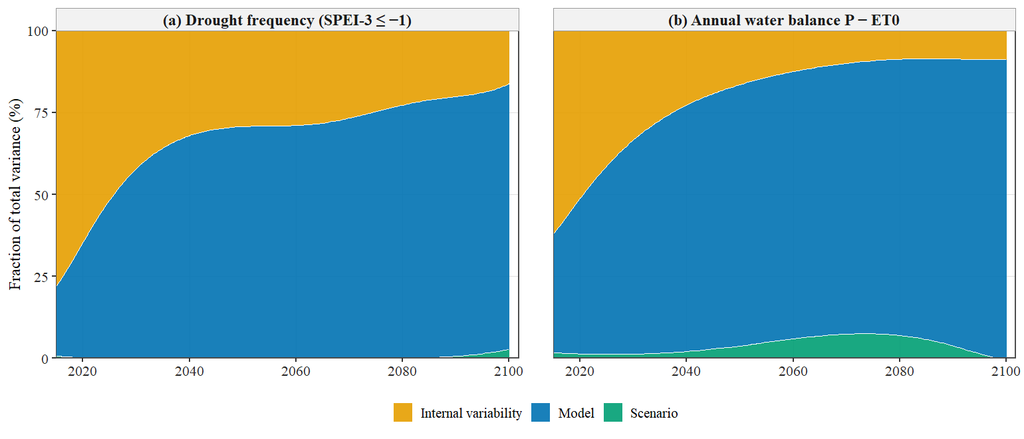

```r
hs_quantity <- function(pr, what) {
  yrs <- sort(unique(pr$years))
  if (what == "WB") { a <- tapply(pr$reg$P - pr$reg$ET0, pr$years, sum) } else
  if (what == "FREQ") { x <- pr$reg$idx[[paste0(SEL_TYPE, SEL_K)]][, 1]; a <- tapply(x <= THR, pr$years, function(z) 100 * mean(z, na.rm = TRUE)) } else
  { x <- pr$reg$idx[[paste0(SEL_TYPE, SEL_K)]][, 1]; a <- tapply(x, pr$years, mean, na.rm = TRUE) }
  a <- as.numeric(a); a - mean(a[yrs >= BASE[1] & yrs <= BASE[2]])
}
HS <- rbindlist(lapply(c(FREQ = "FREQ", WB = "WB"), function(what) {
  yrs <- 1981:2100
  fits <- list(); resv <- c()
  for (mdl in TOP) for (s in SCEN) { y <- hs_quantity(PROJ[[mdl]][[s]], what)
    f <- fitted(lm(y ~ poly(yrs, 4))); fits[[paste(mdl, s, sep = "|")]] <- f
    resv <- c(resv, var(zoo::rollmean(y - f, 10, fill = NA), na.rm = TRUE)) }
  V <- mean(resv); w <- WTS / sum(WTS)
  F <- simplify2array(fits)   # [year, model|scen]
  mods <- sub("\\|.*", "", colnames(F)); scs <- sub(".*\\|", "", colnames(F))
  M <- rowMeans(sapply(SCEN, function(s) { Fs <- F[, scs == s, drop = FALSE]; ws <- w[mods[scs == s]]; ws <- ws / sum(ws)
    mu <- Fs %*% ws; rowSums(sweep((Fs - as.numeric(mu))^2, 2, ws, "*")) }))
  mm <- sapply(SCEN, function(s) { Fs <- F[, scs == s, drop = FALSE]; ws <- w[mods[scs == s]]; ws <- ws / sum(ws); as.numeric(Fs %*% ws) })
  S <- apply(mm, 1, var)
  data.table(what = what, year = yrs, internal = V, model = M, scenario = S)[year >= 2015]
}))
HS[, total := internal + model + scenario]
HSL <- melt(HS, id.vars = c("what", "year", "total"), measure.vars = c("internal", "model", "scenario"), variable.name = "source")
HSL[, frac := 100 * value / total]
HSL[, what := factor(c(FREQ = paste0("(a) Drought frequency (", SEL_NAME, " ≤ −1)"), WB = "(b) Annual water balance P − ET0")[what],
                     levels = c(paste0("(a) Drought frequency (", SEL_NAME, " ≤ −1)"), "(b) Annual water balance P − ET0"))]
fig10 <- ggplot(HSL, aes(year, frac, fill = source)) + geom_area(alpha = 0.9, colour = "white", linewidth = 0.15) +
  facet_wrap(~what) + scale_fill_manual(values = c(internal = "#E69F00", model = "#0072B2", scenario = "#009E73"),
                                        labels = c("Internal variability", "Model", "Scenario"), name = NULL) +
  scale_x_continuous(expand = expansion(mult = c(0, 0.02)), breaks = seq(2020, 2100, 20)) + scale_y_continuous(expand = c(0, 0)) +
  theme(panel.spacing = unit(0.6, "cm")) +
  labs(x = NULL, y = "Fraction of total variance (%)") + theme(legend.position = "bottom")
save_fig(fig10, "Fig10_uncertainty_partition", IEEE2, 3); fig10
```

```r
KEY$hs_fractions <- HSL[year %in% c(2030, 2050, 2075, 2095), .(frac = frac), by = .(what, year, source)]
fwrite(HS, file.path(ROOT, "11_validation_uncertainty", "hawkins_sutton_components.csv"))
```

## 8.4 Sensitivity tests

```r
far <- PERIODS$far
sens_row <- function(lab, fun) rbindlist(lapply(SCEN, function(s) { d <- sapply(TOP, function(mdl) fun(PROJ[[mdl]][[s]]))
  rb <- robust(d); data.table(Test = lab, Scenario = SCEN_LAB[s], `Δ freq far (%-pt)` = sum(WTS * d) / sum(WTS),
                             `Model range` = sprintf("%.1f to %.1f", min(d), max(d)), Robust = rb["robust"] == 1) }))
dfreq <- function(x, pr, thr = THR, base = BASE) 100 * (mean(x[pr$years >= far[1] & pr$years <= far[2]] <= thr, na.rm = TRUE) -
                                                       mean(x[pr$years >= base[1] & pr$years <= base[2]] <= thr, na.rm = TRUE))
T7 <- rbind(
  sens_row(paste0("Reference: ", SEL_NAME, ", PM ET0, threshold −1, baseline 1985–2014"), function(pr) dfreq(pr$reg$idx[[paste0(SEL_TYPE, SEL_K)]][, 1], pr)),
  sens_row(paste0("SPEI-", SEL_K, " with PM ET0"), function(pr) dfreq(pr$reg$spei_sel_pm[, 1], pr)),
  sens_row(paste0(if (SEL_TYPE == "SPI") "SPEI" else SEL_TYPE, "-", SEL_K, " with Hargreaves ET0"), function(pr) dfreq(pr$reg$sel_hg[, 1], pr)),
  sens_row("Threshold −1.5 (instead of −1)", function(pr) dfreq(pr$reg$idx[[paste0(SEL_TYPE, SEL_K)]][, 1], pr, thr = -1.5)),
  sens_row("Alternative baseline 1981–2010 (calibration and reference)", function(pr) dfreq(pr$reg$sel_alt[, 1], pr, base = BASE_ALT)),
  sens_row("No QDM (NEX-GDDP-CMIP6 as published)", function(pr) dfreq(pr$raw$sel, pr)))
pchg <- function(x, pr) 100 * (mean(x[pr$years >= far[1] & pr$years <= far[2]]) / mean(x[pr$years >= BASE[1] & pr$years <= BASE[2]]) - 1)
# ---- v2 sensitivities: QDM without month pooling (item 7a) and TerraClimate (instead of ERA5-Land) QDM targets ----
sens_src <- function(src) sapply(TOP, function(mdl) sapply(SCEN, function(s) { ms <- model_series(mdl, s, src)
  P <- wmean(ms$x$pr, W_REG); E <- wmean(ms$et_pm, W_REG); list(years = ms$years, P = P, ET0 = E, sel = SEL_FUN(P, E, ms$months, ms$years)[, 1]) },
  simplify = FALSE), simplify = FALSE)
SENS_S1 <- cached(paste0("sens_pooled_std_", TOPH), sens_src(QDMX_S1)); SENS_S2 <- cached(paste0("sens_pooled_", TOPH), sens_src(QDMX_S2)); SENS_TC <- cached(paste0("sens_tc_permonth_", TOPH), sens_src(QDMX_TC))
srow2 <- function(lab, S) rbindlist(lapply(SCEN, function(s) { d <- sapply(TOP, function(mdl) dfreq(S[[mdl]][[s]]$sel, S[[mdl]][[s]]))
  rb <- robust(d); data.table(Test = lab, Scenario = SCEN_LAB[s], `Δ freq far (%-pt)` = sum(WTS * d) / sum(WTS),
                             `Model range` = sprintf("%.1f to %.1f", min(d), max(d)), Robust = rb["robust"] == 1) }))
T7 <- rbind(T7, srow2("QDM with standardised ±1-month pooled windows (S1)", SENS_S1), srow2("QDM with unstandardised ±1-month pooled windows (S2, v2.1)", SENS_S2), srow2("QDM to TerraClimate (instead of ERA5-Land) PM targets", SENS_TC))
KEY$qdm_pooling_effect <- rbindlist(lapply(SCEN, function(s) { w <- WTS / sum(WTS)
  data.table(scenario = s, dP_raw = sum(w * sapply(TOP, function(m) pchg(PROJ[[m]][[s]]$raw$P, PROJ[[m]][[s]]))),
             dP_primary = sum(w * sapply(TOP, function(m) pchg(PROJ[[m]][[s]]$reg$P, PROJ[[m]][[s]]))),
             dP_pooled_std = sum(w * sapply(TOP, function(m) pchg(SENS_S1[[m]][[s]]$P, SENS_S1[[m]][[s]]))),
             dP_pooled = sum(w * sapply(TOP, function(m) pchg(SENS_S2[[m]][[s]]$P, SENS_S2[[m]][[s]]))),
             dP_tc = sum(w * sapply(TOP, function(m) pchg(SENS_TC[[m]][[s]]$P, SENS_TC[[m]][[s]])))) }))
KEY$qdm_pooling_effect[, `:=`(inflation_primary_pct_points = dP_primary - dP_raw, inflation_pooled_std_pct_points = dP_pooled_std - dP_raw, inflation_pooled_pct_points = dP_pooled - dP_raw)]
KEY$raw_vs_qdm <- rbindlist(lapply(SCEN, function(s) { d <- rbindlist(lapply(TOP, function(mdl) { pr <- PROJ[[mdl]][[s]]
  data.table(model = mdl, dP_raw = pchg(pr$raw$P, pr), dP_qdm = pchg(pr$reg$P, pr), dET0_raw = pchg(pr$raw$ET0, pr), dET0_qdm = pchg(pr$reg$ET0, pr),
             dfreq_raw = dfreq(pr$raw$sel, pr), dfreq_qdm = dfreq(pr$reg$idx[[paste0(SEL_TYPE, SEL_K)]][, 1], pr)) }))   # v3.1: effect of QDM on the drought signal
  d[, c(list(scenario = s), lapply(.SD, function(x) sum(WTS[model] * x) / sum(WTS[model]))), .SDcols = -"model"] }))
# characteristics with threshold -1.5
TH <- rbindlist(lapply(TOP, function(mdl) rbindlist(lapply(SCEN, function(s) { pr <- PROJ[[mdl]][[s]]; x <- pr$reg$idx[[paste0(SEL_TYPE, SEL_K)]][, 1]
  rbindlist(lapply(c(-1, -1.5), function(th) { b <- char_summary(x, pr$dates, pr$years, BASE, th); f <- char_summary(x, pr$dates, pr$years, far, th)
    data.table(model = mdl, scenario = s, thr = th, dD = f$D_mean - b$D_mean, dS = f$S_mean - b$S_mean, dN = f$events_per_decade - b$events_per_decade) })) }))))
KEY$threshold_sens <- TH[, .(dD = sum(WTS[model] * dD) / sum(WTS[model]), dS = sum(WTS[model] * dS) / sum(WTS[model]), dN = sum(WTS[model] * dN) / sum(WTS[model])), by = .(scenario, thr)]
# observed: PM vs Hargreaves and alternative baseline
obs_sens <- data.table(Test = c("Observed SPEI-12 Dec trend, PM (per decade)", "Observed SPEI-12 Dec trend, Hargreaves (per decade)",
                                paste0("Observed ", SEL_NAME, " drought months 1981–2024, baseline 1985–2014"), paste0("Observed ", SEL_NAME, " drought months 1981–2024, baseline 1981–2010")),
                       value = c(10 * tfpw(IDX_REG$grid$SPEI12[MON_OBS == 12, 1])["slope"], 10 * tfpw(IDX_REG$grid_hg$SPEI12[MON_OBS == 12, 1])["slope"],
                                 sum(IDX_REG$grid[[paste0(SEL_TYPE, SEL_K)]][, 1] <= THR, na.rm = TRUE), sum(IDX_REG$grid_altbase[[paste0(SEL_TYPE, SEL_K)]][, 1] <= THR, na.rm = TRUE)))
KEY$obs_sensitivity <- obs_sens
```

```r
ISI_FILES <- list.files(file.path(ROOT, "06_gcm_eval", "isimip3b_monthly"), "\\.nc$", full.names = TRUE)
ISI <- if (!length(ISI_FILES)) NULL else cached(paste0("isimip_chain_", length(ISI_FILES)), {
  fs <- ISI_FILES
  rbindlist(lapply(intersect(intersect(ISI_MODELS, names(PROJ)), sub("_historical\\.nc$", "", basename(fs[grepl("historical", fs)]))), function(mdl) {
    rd <- function(e) { f <- file.path(ROOT, "06_gcm_eval", "isimip3b_monthly", paste0(mdl, "_", e, ".nc")); if (!file.exists(f)) return(NULL)
      sapply(VARS6, function(v) { r <- rast(f, subds = v); e2 <- terra::extract(r, vect(region), weights = TRUE, exact = TRUE)
        colSums(as.matrix(e2[, -c(1, ncol(e2))]) * e2$weight, na.rm = TRUE) / sum(e2$weight) }) }
    h <- rd("historical"); f <- rd("ssp585"); if (is.null(h) || is.null(f)) return(NULL)
    X <- rbind(h, f); mo <- rep(1:12, length.out = nrow(X)); yr <- rep(1981:2100, each = 12)
    zr <- weighted.mean(ANA$z, W_REG); latr <- weighted.mean(ANA$lat, W_REG)
    et <- pm_monthly(X[, "tasmax", drop = FALSE], X[, "tasmin", drop = FALSE], X[, "rsds", drop = FALSE], X[, "sfcWind", drop = FALSE],
                     ea_from_hurs(X[, "hurs", drop = FALSE], X[, "tasmax", drop = FALSE], X[, "tasmin", drop = FALSE]), zr, latr, mo)
    x <- SEL_FUN(X[, "pr", drop = FALSE], et, mo, yr)[, 1]
    pr0 <- list(years = yr); nex <- PROJ[[mdl]]$ssp585
    data.table(model = mdl, isimip_dfreq = dfreq(x, pr0), nex_dfreq = dfreq(nex$reg$idx[[paste0(SEL_TYPE, SEL_K)]][, 1], nex),
               isimip_dP = 100 * (mean(X[yr >= far[1] & yr <= far[2], "pr"]) / mean(X[yr >= BASE[1] & yr <= BASE[2], "pr"]) - 1),
               nex_dP = 100 * (mean(nex$reg$P[nex$years >= far[1] & nex$years <= far[2]]) / mean(nex$reg$P[nex$years >= BASE[1] & nex$years <= BASE[2]]) - 1),
               isimip_dET0 = 100 * (mean(et[yr >= far[1] & yr <= far[2]]) / mean(et[yr >= BASE[1] & yr <= BASE[2]]) - 1),
               nex_dET0 = 100 * (mean(nex$reg$ET0[nex$years >= far[1] & nex$years <= far[2]]) / mean(nex$reg$ET0[nex$years >= BASE[1] & nex$years <= BASE[2]]) - 1))
  }))
})
if (!is.null(ISI) && nrow(ISI)) {
  T7 <- rbind(T7, data.table(Test = "Second chain: ISIMIP3b (5 GCMs) vs NEX-GDDP+QDM (same GCMs), SSP5-8.5", Scenario = "SSP5-8.5",
                             `Δ freq far (%-pt)` = mean(ISI$isimip_dfreq), `Model range` = sprintf("NEX+QDM: %.1f (%.1f to %.1f)", mean(ISI$nex_dfreq), min(ISI$nex_dfreq), max(ISI$nex_dfreq)),
                             Robust = NA))
  KEY$isimip_chain <- ISI
  fwrite(ISI, file.path(ROOT, "11_validation_uncertainty", "isimip3b_vs_nex.csv"))
}
KEY$sensitivity <- T7
save_table(T7, 7, "Sensitivity of the projected far-future (2076–2100) change in drought frequency", "Table7_sensitivity",
           note = paste0("Skill-weighted mean over the ", NKEEP, " retained models unless stated. Robust as in Table IV. ISIMIP3b provides no SSP2-4.5; its five GCMs (GFDL-ESM4, IPSL-CM6A-LR, MPI-ESM1-2-HR, MRI-ESM2-0, UKESM1-0-LL) are compared with the same GCMs from NEX-GDDP-CMIP6 + QDM (unweighted means)."), digits = 2)
```

TABLE VII SENSITIVITY OF THE PROJECTED FAR-FUTURE (2076–2100) CHANGE IN DROUGHT FREQUENCY

| Test | Scenario | Δ freq far (%-pt) | Model range | Robust |
| --- | --- | --- | --- | --- |
| Reference: SPEI-3, PM ET0, threshold −1, baseline 1985–2014 | SSP2-4.5 | 9.99 | -2.9 to 24.6 | true |
| Reference: SPEI-3, PM ET0, threshold −1, baseline 1985–2014 | SSP5-8.5 | 11.06 | -6.3 to 28.9 | true |
| SPEI-3 with PM ET0 | SSP2-4.5 | 9.99 | -2.9 to 24.6 | true |
| SPEI-3 with PM ET0 | SSP5-8.5 | 11.06 | -6.3 to 28.9 | true |
| SPEI-3 with Hargreaves ET0 | SSP2-4.5 | 11.10 | -0.3 to 26.5 | true |
| SPEI-3 with Hargreaves ET0 | SSP5-8.5 | 12.53 | -7.9 to 30.8 | true |
| Threshold −1.5 (instead of −1) | SSP2-4.5 | 8.38 | -1.7 to 21.1 | true |
| Threshold −1.5 (instead of −1) | SSP5-8.5 | 11.29 | -2.0 to 29.8 | true |
| Alternative baseline 1981–2010 (calibration and reference) | SSP2-4.5 | 8.94 | -3.9 to 22.6 | false |
| Alternative baseline 1981–2010 (calibration and reference) | SSP5-8.5 | 10.10 | -9.3 to 27.0 | true |
| No QDM (NEX-GDDP-CMIP6 as published) | SSP2-4.5 | 11.55 | -0.1 to 25.9 | true |
| No QDM (NEX-GDDP-CMIP6 as published) | SSP5-8.5 | 14.58 | -3.7 to 33.9 | true |
| QDM with standardised ±1-month pooled windows (S1) | SSP2-4.5 | 11.81 | -1.8 to 26.1 | true |
| QDM with standardised ±1-month pooled windows (S1) | SSP5-8.5 | 13.24 | -6.3 to 32.7 | true |
| QDM with unstandardised ±1-month pooled windows (S2, v2.1) | SSP2-4.5 | 12.46 | -0.2 to 28.6 | true |
| QDM with unstandardised ±1-month pooled windows (S2, v2.1) | SSP5-8.5 | 13.89 | -6.7 to 33.6 | true |
| QDM to TerraClimate (instead of ERA5-Land) PM targets | SSP2-4.5 | 8.75 | -2.3 to 22.9 | false |
| QDM to TerraClimate (instead of ERA5-Land) PM targets | SSP5-8.5 | 9.28 | -7.3 to 26.3 | true |
| Second chain: ISIMIP3b (5 GCMs) vs NEX-GDDP+QDM (same GCMs), SSP5-8.5 | SSP5-8.5 | 8.22 | NEX+QDM: 7.5 (-10.5 to 23.6) |  |

Skill-weighted mean over the 10 retained models unless stated. Robust as in Table IV. ISIMIP3b provides no SSP2-4.5; its five GCMs (GFDL-ESM4, IPSL-CM6A-LR, MPI-ESM1-2-HR, MRI-ESM2-0, UKESM1-0-LL) are compared with the same GCMs from NEX-GDDP-CMIP6 + QDM (unweighted means).

```r
T7
```

| Test | Scenario | Δ freq far (%-pt) | Model range | Robust |
| --- | --- | --- | --- | --- |
| Reference: SPEI-3, PM ET0, threshold −1, baseline 1985–2014 | SSP2-4.5 | 9.991243 | -2.9 to 24.6 | TRUE |
| Reference: SPEI-3, PM ET0, threshold −1, baseline 1985–2014 | SSP5-8.5 | 11.058756 | -6.3 to 28.9 | TRUE |
| SPEI-3 with PM ET0 | SSP2-4.5 | 9.991243 | -2.9 to 24.6 | TRUE |
| SPEI-3 with PM ET0 | SSP5-8.5 | 11.058756 | -6.3 to 28.9 | TRUE |
| SPEI-3 with Hargreaves ET0 | SSP2-4.5 | 11.095978 | -0.3 to 26.5 | TRUE |
| SPEI-3 with Hargreaves ET0 | SSP5-8.5 | 12.529930 | -7.9 to 30.8 | TRUE |
| Threshold −1.5 (instead of −1) | SSP2-4.5 | 8.379389 | -1.7 to 21.1 | TRUE |
| Threshold −1.5 (instead of −1) | SSP5-8.5 | 11.290595 | -2.0 to 29.8 | TRUE |
| Alternative baseline 1981–2010 (calibration and reference) | SSP2-4.5 | 8.936514 | -3.9 to 22.6 | FALSE |
| Alternative baseline 1981–2010 (calibration and reference) | SSP5-8.5 | 10.097458 | -9.3 to 27.0 | TRUE |
| No QDM (NEX-GDDP-CMIP6 as published) | SSP2-4.5 | 11.548931 | -0.1 to 25.9 | TRUE |
| No QDM (NEX-GDDP-CMIP6 as published) | SSP5-8.5 | 14.583918 | -3.7 to 33.9 | TRUE |
| QDM with standardised ±1-month pooled windows (S1) | SSP2-4.5 | 11.813152 | -1.8 to 26.1 | TRUE |
| QDM with standardised ±1-month pooled windows (S1) | SSP5-8.5 | 13.244520 | -6.3 to 32.7 | TRUE |
| QDM with unstandardised ±1-month pooled windows (S2, v2.1) | SSP2-4.5 | 12.456526 | -0.2 to 28.6 | TRUE |
| QDM with unstandardised ±1-month pooled windows (S2, v2.1) | SSP5-8.5 | 13.889036 | -6.7 to 33.6 | TRUE |
| QDM to TerraClimate (instead of ERA5-Land) PM targets | SSP2-4.5 | 8.746831 | -2.3 to 22.9 | FALSE |
| QDM to TerraClimate (instead of ERA5-Land) PM targets | SSP5-8.5 | 9.275768 | -7.3 to 26.3 | TRUE |
| Second chain: ISIMIP3b (5 GCMs) vs NEX-GDDP+QDM (same GCMs), SSP5-8.5 | SSP5-8.5 | 8.222222 | NEX+QDM: 7.5 (-10.5 to 23.6) | NA |

## 8.5 Sensitivity to the model set (v2.1, Phase B)

Within each set the models are weighted ∝ 1/L (entropy weights, full sample), and robustness is assessed as in Table IV.

```r
L2w <- setNames(1 / CP$L, CP$model)                                   # weights ∝ 1/L (entropy) in every set
SETS <- list(`primary (v3.1 selection)` = TOP, `v3 primary (before the v3.1 code fixes)` = intersect(unlist(cfg$ensemble$v3_primary_set), names(PROJ)), `v2.2 primary (open-data stations only)` = intersect(unlist(cfg$ensemble$v22_primary_set), names(PROJ)), `old 10 (v2.1 primary)` = intersect(V21_SET, names(PROJ)), `primary without models with a source discontinuity` = setdiff(TOP, DISC$model),
             `old (TerraClimate reference, v2)` = intersect(TOP_OLD, names(PROJ)), `all models with scenario data` = intersect(SCEN_AVAIL, names(PROJ)))
set_metrics <- function(ms) {
  w <- L2w[ms] / sum(L2w[ms]); out <- list()
  for (s in SCEN) {
    d <- CHG_ALL[model %in% ms & scenario == s & period == "far"]; rb <- robust(d$d_freq)
    # pooled-ensemble Bernstein T_AND of the primary reference 25-yr event
    t25 <- function(per) { ev <- rbindlist(lapply(ms, function(m) ev_period(PROJ[[m]][[s]], per)$ev)); yrs <- length(ms) * (per[2] - per[1] + 1)
      fx <- tryCatch(fit_one(ev, yrs), error = function(e) NULL); if (is.null(fx)) NA_real_ else unname(as.numeric(T3(fx, REF$d[2], REF$s[2])[1, "bernstein"])) }
    tset <- c(BASE = t25(BASE), FAR = t25(PERIODS$far))
    # graded wheat exposure (frequency-weighted), set-specific cell frequencies
    fbm <- rbindlist(lapply(ms, function(m) { pr <- PROJ[[m]][[s]]; X <- pr$cell_sel
      data.table(model = m, cell = seq_len(ncol(X)), fb = 100 * colMeans(X[pr$years >= BASE[1] & pr$years <= BASE[2], ] <= THR, na.rm = TRUE)) }))
    cc <- merge(CELLCHG_ALL[model %in% ms & scenario == s & period == "far"], fbm, by = c("model", "cell"))[, .(fb = sum(w[model] * fb) / sum(w[model]), d = sum(w[model] * d_freq) / sum(w[model])), by = cell]
    cc <- cbind(cc, ANA[cc$cell, .(lon, lat)])[, ck := paste(round(lon, 3), round(lat, 3))]
    mm <- merge(PIX, cc[, .(ck, fb, ff = pmax(fb + d, 0))], by = "ck")
    out[[s]] <- data.table(scenario = SCEN_LAB[s], n_models = length(ms), d_freq = sum(w[d$model] * d$d_freq), robust = rb[["robust"]] == 1, agree = rb[["agree"]],
                           d_P = sum(w[d$model] * d$d_P), d_ET0 = sum(w[d$model] * d$d_ET0), T25_base = tset[["BASE"]], T25_far = tset[["FAR"]],
                           dE_wheat = 100 * (sum(mm$wheat * mm$ff) / sum(mm$wheat * mm$fb) - 1))
  }
  rbindlist(out)
}
MSET <- rbindlist(lapply(names(SETS), function(nm) cbind(set = nm, set_metrics(SETS[[nm]]))))
KEY$model_set_sensitivity <- MSET; KEY$model_sets <- lapply(SETS, identity)
fwrite(MSET, file.path(ROOT, "11_validation_uncertainty", "model_set_sensitivity.csv"))
TS6 <- MSET[, .(`Model set` = set, Scenario = scenario, `n GCMs` = n_models, `Δ frequency far (%-pt)` = sprintf("%.1f%s", d_freq, ifelse(robust, "†", "")),
                `Δ P far (%)` = round(d_P, 1), `Δ ET0 far (%)` = round(d_ET0, 1), `T_AND 25-yr: baseline / far (yr)` = sprintf("%.1f / %.1f", T25_base, T25_far),
                `Δ frequency-weighted wheat exposure (%)` = round(dE_wheat, 1))]
save_table(TS6, "S6", "Sensitivity of the key far-future (2076–2100) results to the GCM set", "TableS6_model_set_sensitivity",
           note = "Weights ∝ 1/L2 of the current ranking within each set. † robust (≥80% sign agreement and Wilcoxon p < 0.05). T_AND: pooled-ensemble Bernstein copula of the primary 25-yr reference event.", digits = 1)
```

TABLE S6 SENSITIVITY OF THE KEY FAR-FUTURE (2076–2100) RESULTS TO THE GCM SET

| Model set | Scenario | n GCMs | Δ frequency far (%-pt) | Δ P far (%) | Δ ET0 far (%) | T_AND 25-yr: baseline / far (yr) | Δ frequency-weighted wheat exposure (%) |
| --- | --- | --- | --- | --- | --- | --- | --- |
| primary (v3.1 selection) | SSP2-4.5 | 10 | 10.0† | 15.7 | 7.7 | 50.1 / 9.5 | 61.8 |
| primary (v3.1 selection) | SSP5-8.5 | 10 | 11.1† | 31.5 | 12.4 | 50.1 / 10.0 | 70.9 |
| v3 primary (before the v3.1 code fixes) | SSP2-4.5 | 10 | 8.9† | 15.7 | 7.6 | 65.8 / 10.2 | 55.4 |
| v3 primary (before the v3.1 code fixes) | SSP5-8.5 | 10 | 10.1† | 31.1 | 12.3 | 65.8 / 9.6 | 66.1 |
| v2.2 primary (open-data stations only) | SSP2-4.5 | 10 | 10.1† | 16.5 | 7.8 | 84.5 / 10.1 | 61.7 |
| v2.2 primary (open-data stations only) | SSP5-8.5 | 10 | 11.6† | 30.9 | 12.6 | 84.5 / 8.7 | 74.1 |
| old 10 (v2.1 primary) | SSP2-4.5 | 10 | 10.7† | 14.3 | 7.7 | 99.6 / 9.6 | 65.4 |
| old 10 (v2.1 primary) | SSP5-8.5 | 10 | 12.8† | 28.7 | 12.5 | 99.6 / 8.1 | 81.7 |
| primary without models with a source discontinuity | SSP2-4.5 | 8 | 8.1 | 19.1 | 7.3 | 55.1 / 11.3 | 50.8 |
| primary without models with a source discontinuity | SSP5-8.5 | 8 | 9.1† | 34.4 | 11.6 | 55.1 / 10.9 | 58.1 |
| old (TerraClimate reference, v2) | SSP2-4.5 | 10 | 7.5† | 18.1 | 7.1 | 72.8 / 15.6 | 46.0 |
| old (TerraClimate reference, v2) | SSP5-8.5 | 10 | 10.7† | 32.5 | 12.4 | 72.8 / 9.7 | 69.3 |
| all models with scenario data | SSP2-4.5 | 27 | 8.3 | 16.2 | 7.3 | 95.4 / 12.5 | 52.4 |
| all models with scenario data | SSP5-8.5 | 27 | 9.9† | 32.9 | 12.2 | 95.4 / 11.5 | 64.8 |

Weights ∝ 1/L2 of the current ranking within each set. † robust (≥80% sign agreement and Wilcoxon p < 0.05). T_AND: pooled-ensemble Bernstein copula of the primary 25-yr reference event.

```r
TS6
```

| Model set | Scenario | n GCMs | Δ frequency far (%-pt) | Δ P far (%) | Δ ET0 far (%) | T_AND 25-yr: baseline / far (yr) | Δ frequency-weighted wheat exposure (%) |
| --- | --- | --- | --- | --- | --- | --- | --- |
| primary (v3.1 selection) | SSP2-4.5 | 10 | 10.0† | 15.7 | 7.7 | 50.1 / 9.5 | 61.8 |
| primary (v3.1 selection) | SSP5-8.5 | 10 | 11.1† | 31.5 | 12.4 | 50.1 / 10.0 | 70.9 |
| v3 primary (before the v3.1 code fixes) | SSP2-4.5 | 10 | 8.9† | 15.7 | 7.6 | 65.8 / 10.2 | 55.4 |
| v3 primary (before the v3.1 code fixes) | SSP5-8.5 | 10 | 10.1† | 31.1 | 12.3 | 65.8 / 9.6 | 66.1 |
| v2.2 primary (open-data stations only) | SSP2-4.5 | 10 | 10.1† | 16.5 | 7.8 | 84.5 / 10.1 | 61.7 |
| v2.2 primary (open-data stations only) | SSP5-8.5 | 10 | 11.6† | 30.9 | 12.6 | 84.5 / 8.7 | 74.1 |
| old 10 (v2.1 primary) | SSP2-4.5 | 10 | 10.7† | 14.3 | 7.7 | 99.6 / 9.6 | 65.4 |
| old 10 (v2.1 primary) | SSP5-8.5 | 10 | 12.8† | 28.7 | 12.5 | 99.6 / 8.1 | 81.7 |
| primary without models with a source discontinuity | SSP2-4.5 | 8 | 8.1 | 19.1 | 7.3 | 55.1 / 11.3 | 50.8 |
| primary without models with a source discontinuity | SSP5-8.5 | 8 | 9.1† | 34.4 | 11.6 | 55.1 / 10.9 | 58.1 |
| old (TerraClimate reference, v2) | SSP2-4.5 | 10 | 7.5† | 18.1 | 7.1 | 72.8 / 15.6 | 46.0 |
| old (TerraClimate reference, v2) | SSP5-8.5 | 10 | 10.7† | 32.5 | 12.4 | 72.8 / 9.7 | 69.3 |
| all models with scenario data | SSP2-4.5 | 27 | 8.3 | 16.2 | 7.3 | 95.4 / 12.5 | 52.4 |
| all models with scenario data | SSP5-8.5 | 27 | 9.9† | 32.9 | 12.2 | 95.4 / 11.5 | 64.8 |

# 9 Supplementary figures

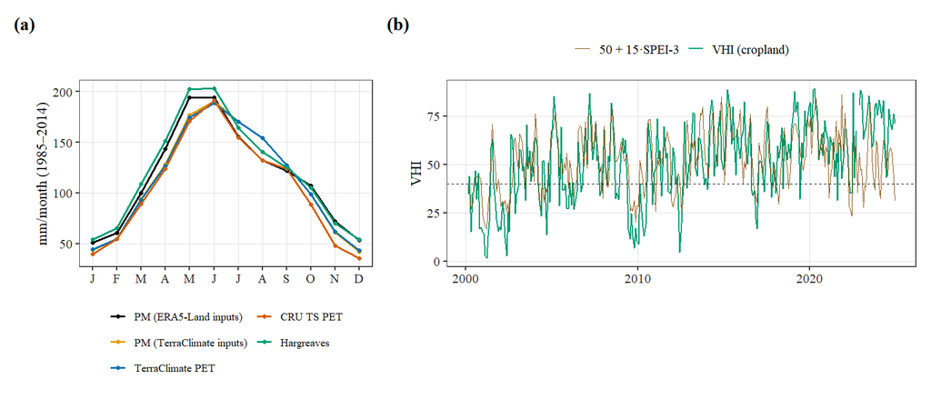

```r
ec <- REG[year >= BASE[1] & year <= BASE[2], .(`PM (ERA5-Land inputs)` = mean(ET0_pm), `PM (TerraClimate inputs)` = mean(ET0_pm_tc), `TerraClimate PET` = mean(PET_tc), `CRU TS PET` = mean(PET_cru), Hargreaves = mean(ET0_hg)), by = month]
KEY$et0_annual <- ec[, lapply(.SD, sum), .SDcols = -"month"]
KEY$et0_r_tc <- cor(REG$ET0_pm, REG$PET_tc); KEY$et0_r_cru <- cor(REG$ET0_pm, REG$PET_cru, use = "complete.obs")
pS1a <- ggplot(melt(ec, id.vars = "month"), aes(month, value, colour = variable)) + geom_line(linewidth = 0.5) + geom_point(size = 0.8) +
  scale_colour_manual(values = OKABE[c(1, 2, 6, 7, 4)], name = NULL) + scale_x_continuous(breaks = 1:12, labels = substr(month.abb, 1, 1)) +
  labs(x = NULL, y = "mm/month (1985–2014)", tag = "(a)") + guides(colour = guide_legend(ncol = 2)) + theme(legend.position = "bottom", legend.text = element_text(size = 6))
vv <- merge(VH, data.table(date = DATES_OBS, SPEI3 = IDX_REG$grid$SPEI3[, 1]), by = "date")
pS1b <- ggplot(vv, aes(date)) + geom_line(aes(y = VHI, colour = "VHI (cropland)"), linewidth = 0.35) +
  geom_line(aes(y = 50 + 15 * SPEI3, colour = "50 + 15·SPEI-3"), linewidth = 0.3) + geom_hline(yintercept = 40, linetype = "dashed", linewidth = 0.3) +
  scale_colour_manual(values = c(`VHI (cropland)` = "#009E73", `50 + 15·SPEI-3` = "#8c510a"), name = NULL) + labs(x = NULL, y = "VHI", tag = "(b)") +
  theme(legend.position = "top")
figS1 <- if (HAS_VHI) pS1a + pS1b + plot_layout(widths = c(1, 1.6)) else pS1a
save_fig(figS1, "FigS1_ET0_comparison_VHI", IEEE2, 3); figS1
```

# 10 Key numbers and session information

```r
KDIR <- if (DEV) FIG else file.path(ROOT, "results_text")
for (wf in list.files(dirname(WLOG), pattern = "^warnings\\.log\\.[0-9]+$", full.names = TRUE)) { cat(readLines(wf), sep = "\n", file = WLOG, append = TRUE); cat("\n", file = WLOG, append = TRUE); file.remove(wf) }
KEY$n_warnings_logged <- sum(nzchar(trimws(readLines(WLOG))))   # parallel workers append to the same file; a line can hold two messages
jsonlite::write_json(KEY, file.path(KDIR, "key_numbers.json"), auto_unbox = TRUE, pretty = TRUE, digits = 6)
saveRDS(KEY, file.path(KDIR, "key_numbers.rds"))
# results of every variant computed downstream (PREREGISTRATION general rule): Item 2 duration rule, Item 3 QDM variants in
# the projections, Item 4 model sets, and the Table VII sensitivities
for (k in seq_len(nrow(RPRULE))) { x <- RPRULE[k]; lab <- paste0(x$set, ", T", x$T_ref, ", ", x$estimator)
  add_variant("2", paste0("whole-month rule (v2.2): ", lab), "primary", "T_AND (yr)", x$T_new); add_variant("2", paste0("continuous rule (v2.1): ", lab), "sensitivity", "T_AND (yr)", x$T_old_rule) }
for (k in seq_len(nrow(KEY$qdm_pooling_effect))) { x <- KEY$qdm_pooling_effect[k]
  for (cc in c("dP_raw", "dP_primary", "dP_pooled_std", "dP_pooled", "dP_tc")) add_variant("3", paste0(cc, " (", x$scenario, ")"),
    switch(cc, dP_raw = "reference", dP_primary = "primary", "sensitivity"), "far-future regional P change (%)", x[[cc]]) }
for (k in seq_len(nrow(MSET))) { x <- MSET[k]; lab <- paste0(x$set, " (", x$scenario, ")"); rl <- if (startsWith(x$set, "primary (v3")) "primary" else "sensitivity"
  for (cc in c("d_freq", "agree", "d_P", "d_ET0", "T25_base", "T25_far", "dE_wheat")) add_variant("4", lab, rl, cc, x[[cc]]) }
for (k in seq_len(nrow(T7))) { x <- T7[k]; add_variant("general", paste0(x$Test, " (", x$Scenario, ")"), if (startsWith(x$Test, "Reference")) "primary" else "sensitivity", "Δ freq far (%-pt)", x[["Δ freq far (%-pt)"]]) }
# v3: hydrological input (WAPDA gauges primary; GloFAS same years / full record) and gauge calibration period
for (nm in c("propagation", "propagation_glofas_1981_2003", "propagation_glofas")) { x <- KEY[[nm]]
  add_variant("v3", paste0(nm, " (", x$period, ")"), if (nm == "propagation") "primary" else "sensitivity", "max r SPEI-k vs SRI-1, Dhok Pathan", x$r)
  add_variant("v3", paste0(nm, " (", x$period, ")"), if (nm == "propagation") "primary" else "sensitivity", "best k (months)", x$best_k) }
for (k in seq_len(nrow(KEY$wapda_sri3))) { x <- KEY$wapda_sri3[k]
  add_variant("v3", paste0("gauge SRI-3 calibration 1985–2003: ", x$gauge), "primary", "SRI-3 drought months 1981–2003 (%)", x$drought_pct_1981_2003)
  add_variant("v3", paste0("gauge SRI-3 calibration 1974–2003: ", x$gauge), "sensitivity", "SRI-3 drought months 1981–2003 (%)", x$drought_pct_1981_2003_altref) }
dir.create(file.path(ROOT, "sensitivity"), showWarnings = FALSE); fwrite(rbindlist(VARIANT_ROWS), file.path(ROOT, "sensitivity", "all_variants.csv"))
if (!DEV) {   # documents generated from the key numbers (R/officer): results text and methodology redline
  source(file.path(ROOT, "scripts", "12_results_discussion.R"), local = new.env())
  source(file.path(ROOT, "scripts", "13_methodology_redline.R"), local = new.env())
  source(file.path(ROOT, "scripts", "15_render_deviations.R"), local = new.env())
}
```

```
## Results_Discussion.docx written; 410 numbers logged
## redline written: 20 changes; original text located for 20 of 20
## DEVIATIONS.md rendered: 77 placeholders substituted
```

```r
cat("Run time:", round(difftime(Sys.time(), t_start, units = "mins"), 1), "minutes\n")
```

```
## Run time: 2.4 minutes
```